# Homework 3

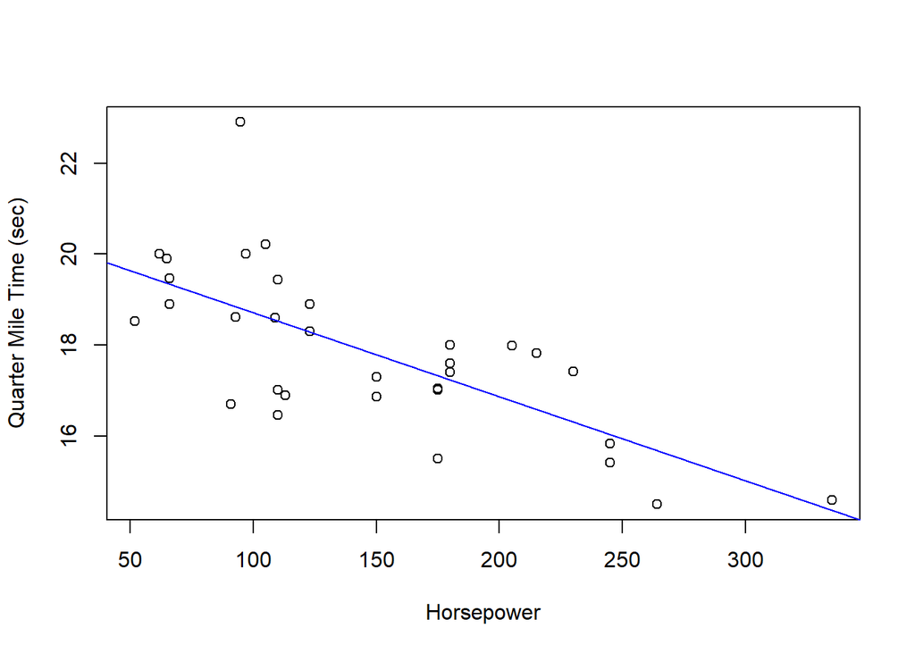

```r
#c fitting a linear regression
plot(mtcars$hp,mtcars$qsec, xlab= "Horsepower", ylab= "Quarter Mile Time (sec)")
abline((my.fit2), col="blue")
```

```r
#d)
my.fit2
```

```
##
## Call:  glm(formula = mtcars$qsec ~ mtcars$hp)
##
## Coefficients:
## (Intercept)    mtcars$hp
##    20.55635     -0.01846
##
## Degrees of Freedom: 31 Total (i.e. Null);  30 Residual
## Null Deviance:       98.99
## Residual Deviance: 49.34     AIC: 110.7
```

```r
y=-0.01846*300 + 20.55635
y
```

```
## [1] 15.01835
```

#since y=-0.01846x + 20.55635, when the horsepower is 300 (y=-0.01846*300 + 20.55635) the quater mile time is 15.02 seconds #e (mistake in the question, it asks for relation between gas mileage and car weight, I’m guessing this is supposed to ask for the relationship between horsepower and quarter mile time) Quarter mile time is significantly related to horsepower (p=5.77e-06)

```r
#f testing for assumptions
#gvlma was installed
library(gvlma)
gvlma(lm(my.fit2))
```

```
##
## Call:
## lm(formula = my.fit2)
##
## Coefficients:
## (Intercept)    mtcars$hp
##    20.55635     -0.01846
##
##
## ASSESSMENT OF THE LINEAR MODEL ASSUMPTIONS
## USING THE GLOBAL TEST ON 4 DEGREES-OF-FREEDOM:
## Level of Significance =  0.05
##
## Call:
##  gvlma(x = lm(my.fit2))
##
##                       Value p-value                   Decision
## Global Stat        8.148631 0.08628    Assumptions acceptable.
## Skewness           2.876131 0.08990    Assumptions acceptable.
## Kurtosis           4.338691 0.03726 Assumptions NOT satisfied!
## Link Function      0.001639 0.96771    Assumptions acceptable.
## Heteroscedasticity 0.932170 0.33430    Assumptions acceptable.
```

#f) The data met all the required assumptions except for Kurtosis (p<0.05). The residuals were not normally distributed.

```r
#15 Prices of Horses
horse.data<-read.csv("HorsePrices.csv")
horse.data
```

```
##     X HorseID Price  Age Height Sex
## 1   1      97 38000  3.0  16.75   m
## 2   2     156 40000  5.0  17.00   m
## 3   3      56 10000  1.0     NA   m
## 4   4     139 12000  8.0  16.00   f
## 5   5      65 25000  4.0  16.25   m
## 6   6     184 35000  8.0  16.25   f
## 7   7      88 35000  5.0  16.50   m
## 8   8     182 12000 17.0  16.75   f
## 9   9     101 22000  4.0  17.25   m
## 10 10     135 25000  6.0  15.25   f
## 11 11      35 40000  7.0  16.75   m
## 12 12      39 25000  7.0  15.75   f
## 13 13     198  4500 14.0  16.00   f
## 14 14     107 19900  6.0  15.50   m
```

[output cut: 36 more lines]

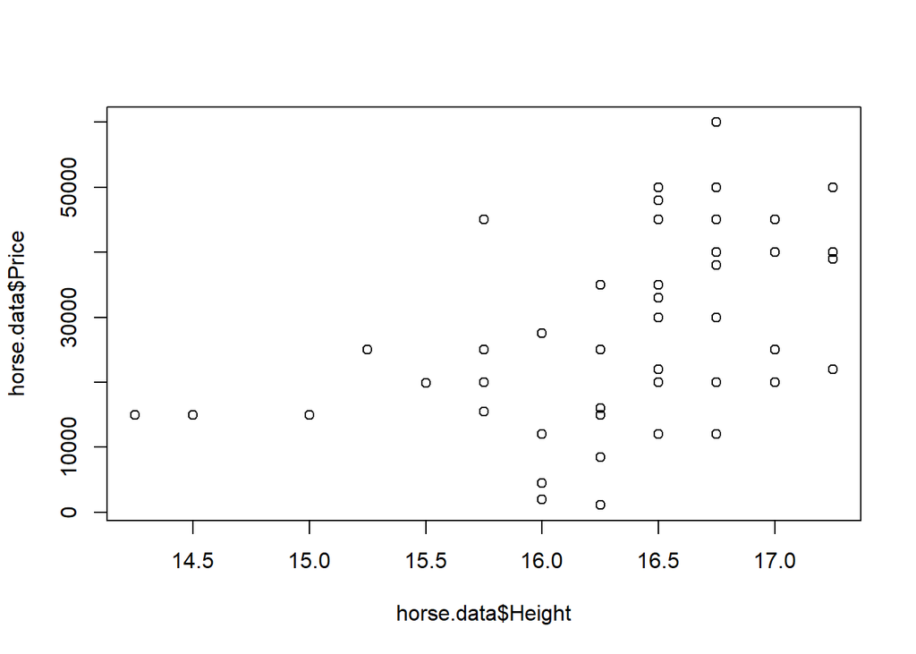

```r
#b Is horse height and selling price correlated?
plot(horse.data$Price~horse.data$Height)
```

```r
#c
horse.fit=glm(horse.data$Price~horse.data$Height)
summary.lm(horse.fit)
```

```
##
## Call:
## glm(formula = horse.data$Price ~ horse.data$Height)
##
## Residuals:
##    Min     1Q Median     3Q    Max
## -26067 -11167   1928   7833  27880
##
## Coefficients:
##                   Estimate Std. Error t value Pr(>|t|)
## (Intercept)        -133791      48817  -2.741  0.00876 **
## horse.data$Height     9905       2987   3.316  0.00181 **
## ---
## Signif. codes:  0 '***' 0.001 '**' 0.01 '*' 0.05 '.' 0.1 ' ' 1
##
## Residual standard error: 13360 on 45 degrees of freedom
##   (3 observations deleted due to missingness)
## Multiple R-squared:  0.1964, Adjusted R-squared:  0.1785
## F-statistic:    11 on 1 and 45 DF,  p-value: 0.001812
```

```r
#c Testing for correlation: take the square root of the Multiple R-sqaured value (0.1964)
sqrt(0.1964)
```

```
## [1] 0.4431704
```

```r
#Therefore, r=0.4431704
```

#d)The correlation between horse price and horse height is significant (p=0.00181, p<0.05)